# PSYCH 260

2020-10-13 09:13:38

## Prelude

[video not shown]

## Prelude

[video not shown]

## Today’s Topics

- Exam 2 this Thursday (40 questions)
- Evolution and U.S. public attitudes
- The evolution of the human brain

## Evolution and U.S. public attitudes

## Public acceptance of evolution

[figure not shown]

[(Miller, Scott, & Okamoto, 2006)](http://dx.doi.org/10.1126/science.1126746)

## Principles of evolution

- Life forms existing in the Earth’s past differed from those living today
- New generations of life forms inherit properties from their predecessors
- New life forms evolved as a result of *mutations*, *selection pressures*, and *geological events*
- Greater survival/reproductive success for some, not others

## Evidence for evolution

- Fossil
  - Fossil dating (radiometric)
- Geological
  - Where fossils are found relative to one another (relative dating)
  - How long it takes to form layers

## Types of evidence

- Molecular
  - Similarities between vastly different species (e.g., in neurotransmitters, receptors, metabolic pathways, etc.)
- Genetic
  - Rates of mutation
  - Developmental patterns of gene expression
- Anatomical

[figure not shown]

By Волков Владислав Петрович - Own work, [CC BY-SA 4.0](https://creativecommons.org/licenses/by-sa/4.0), [Link](https://commons.wikimedia.org/w/index.php?curid=37704829)

## *Nothing in Biology Makes Sense Except in the Light of Evolution*

> *“Seen in the light of evolution, biology is, perhaps, intellectually the most satisfying and inspiring science. Without that light, it becomes a pile of sundry facts some of them interesting or curious, but making no meaningful picture as a whole.”*

[(Dobzhansky, 1973)](http://dx.doi.org/10.2307/4444260)

## Why Gilmore thinks it’s controversial (in the U.S.)

- Contradicts verbatim/non-metaphorical reading of some religious texts
- Makes humans seem less special
- Time scales involved beyond human experience
- Scientific method vs. other ways of knowing
- Found in nature ≠ good for human society

## Why Gilmore thinks it’s controversial (in the U.S.)

- Few negative consequences of ‘disbelief’
- U.S. culture individualistic, skeptical of experts & [expertise](https://images-na.ssl-images-amazon.com/images/I/51ZrSRpQg9L._SX329_BO1,204,203,200_.jpg)
- Lower levels of religious belief among [U.S. scientists](http://news.rice.edu/2015/12/03/first-worldwide-survey-of-religion-and-science-no-not-all-scientists-are-atheists/)
- [Politics](http://www.people-press.org/2009/07/09/section-4-scientists-politics-and-religion/)

## Evolution of the human brain

## The dawn of time

[figure not shown]

## History of life on Earth

[figure not shown]

## Time scales

[figure not shown]

## Cambrian Explosion

[video not shown]

## What sparked the explosion? [(Fox, 2016)](http://doi.org/10.1038/530268a)

- Behavior requires movement through space
- Behavior requires coordinating perception with action
- Behavior requires perception at a distance
- Behavior requires **energy**

## How nervous systems differ

- Body symmetry
  - radial
  - bilateral
- Segmentation
- Centralized vs. distributed function
- Cephalization: sense organs & nervous system concentrated in anterior
- Encasement in bone (vertebrates)

## [(Arendt, Tosches, & Marlow, 2016)](http://doi.org/10.1038/nrn.2015.15)

[figure not shown]

## Cellular/molecular mechanisms

- Similarities in patterns of early nervous system development
  - across vastly different species
  - with very distant (in time) common ancestors
  - limited number of successful ways to build nervous systems that successfully regulate behavior

## [(Arendt et al., 2016)](http://doi.org/10.1038/nrn.2015.15)

[figure not shown]

## Comparing brain structures

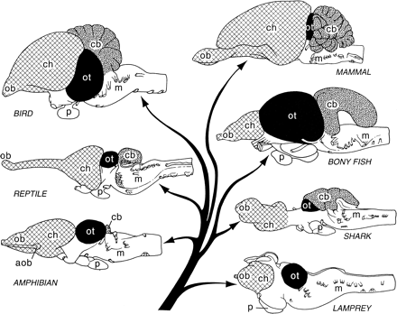

(Northcutt, 2002)

## Comparing brain structures

- Vertebrates have similar brain plans
- Species differ in relative size of parts

## Brain sizes differ by vertebrate groups

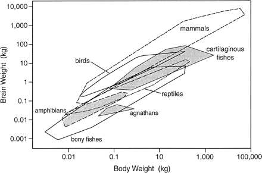

(Northcutt, 2002)

## But have similar “slopes”

- Brain sizes scale with body size

## Comparing brain sizes

[figure not shown]

## Brain sizes across vertebrate groups

- Brain size scales with body size (more or less)
- Mammals and birds have big brains
- Some animals have big brains for their bodies (=high encephalization)
  - Humans
  - Crows
  - Porpoises

## Cortical size within groups

[figure not shown]

[(Hofman, 2014)](http://doi.org/10.3389/fnana.2014.00015)

## Evolutionary trends in cortical size

| Structural measure | Non-human comparison | Human |
| --- | --- | --- |
| Cortical gray matter %/tot brain vol | insectivores 25% | 50% |
| Cortical gray + white | mice 40% | 80% |
| Cerebellar mass | primates, mammals 10-15% | 10-15% |

## Evolutionary trends in cortical size

[figure not shown]

[(Rakic, 2009)](http://dx.doi.org/10.1038/nrn2719)

## Evolutionary trends in primate brain size

[figure not shown]

## Evolutionary trends

- In primates, including humans
  - Smaller olfactory bulbs
  - Cerebellum comparable to other mammals
  - Large cerebral cortex

## Selection pressures

- Natural and sexual selection for
  - Traits that improve reproductive success
- Physical AND psychological traits
  - Hardware and software

## Samsung Galaxy S8

[figure not shown]

## Apple iPhone X

[figure not shown]

## Virtues of big phones/brains

- More storage
- More processing capacity
- Better sensors
- Better output
- More, better apps
- Do more, faster

## Costs of big brains

- Long time to build
- Lots of energy to nourish/maintain
- Long time to program/train/educate
- Head/neck must be strong enough to carry
- How to connect brain/body parts widely, but process info quickly

## Does size matter? Maybe not so much.

[figure not shown]

## A new view (Herculano-Houzel, 2016)

- **Number** of neurons in *cerebral cortex* makes humans “special”

| Species | # cortical neurons | cortical mass (g) |
| --- | --- | --- |
| Human | 16 B | 1233 |
| Chimpanzee | 6 B | 286 |
| Elephant | 5.6 B | 2800 |
| Baboon | 2.9 B | 120.2 |

## A new view (Herculano-Houzel, 2016)

| Species | # cortical neurons | cortical mass (g) |
| --- | --- | --- |
| Giraffe | 1.7 B | 398.8 |
| Rhesus | 1.7 B | 69.8 |
| Pig | 303 M | 42.2 |
| Rabbit | 71 M | 4.4 |

## But humans follow typical scaling rules

[figure not shown]

[(Herculano-Houzel, 2012)](http://doi.org/10.1073/pnas.1201895109)

## # of cortical (or its equivalent) neurons predicts “cognition”?

[figure not shown]

[(Herculano-Houzel, 2017)](http://doi.org/10.1016/j.cobeha.2017.02.004)

## How did it get this way?

- Build upon mammalian/primate norms
- More efficient energy intake
  - calories/hr foraging vs.
  - cooking?
- Prolonged (in time) pattern of development
- Specialized pattern of development
  - Significant time post-natal/pre-reproductive (childhood)

## Take homes

- Life forms on Earth have evolved over *billions* of years
- Nervous systems emerged ~500-600 *million* years ago
- Centralized nervous systems have similarities in organization
- Human brains similar to closely related species, but more cortical neurons

## References

Arendt, D., Tosches, M. A., & Marlow, H. (2016). From nerve net to nerve ring, nerve cord and brain — evolution of the nervous system. *Nature Reviews Neuroscience*, *17*(1), 61–72. https://doi.org/10.1038/nrn.2015.15

Dobzhansky, T. (1973). Nothing in biology makes sense except in the light of evolution. *The American Biology Teacher*, *35*(3), pp. 125–129. Retrieved from http://www.jstor.org/stable/4444260

Fox, D. (2016). What sparked the Cambrian explosion? *Nature*, *530*(7590), 268–270. https://doi.org/10.1038/530268a

Herculano-Houzel, S. (2012). The remarkable, yet not extraordinary, human brain as a scaled-up primate brain and its associated cost. *Proc. Natl. Acad. Sci. U. S. A.*, *109 Suppl 1*, 10661–10668. https://doi.org/10.1073/pnas.1201895109

Herculano-Houzel, S. (2016). *The human advantage: A new understanding of how our brain became remarkable*. MIT Press. Retrieved from https://market.android.com/details?id=book-DMqpCwAAQBAJ

Herculano-Houzel, S. (2017). Numbers of neurons as biological correlates of cognitive capability. *Current Opinion in Behavioral Sciences*, *16*(Supplement C), 1–7. https://doi.org/10.1016/j.cobeha.2017.02.004

Hofman, M. A. (2014). Evolution of the human brain: When bigger is better. *Frontiers in Neuroanatomy*, *8*. https://doi.org/10.3389/fnana.2014.00015

Miller, J. D., Scott, E. C., & Okamoto, S. (2006). Public acceptance of evolution. *SCIENCE-NEW YORK THEN WASHINGTON-*, *313*(5788), 765. https://doi.org/10.1126/science.1126746

Northcutt, R. G. (2002). Understanding Vertebrate Brain Evolution. *Integrative and Comparative Biology*, *42*(4), 743–756. https://doi.org/10.1093/icb/42.4.743

Rakic, P. (2009). Evolution of the neocortex: A perspective from developmental biology. *Nature Reviews Neuroscience*, *10*(10), 724–735. https://doi.org/10.1038/nrn2719